# Reproducible Research: Peer Assessment Project 1

## 0. Loading and preprocessing the data

0.1. Download the folder for this repository and set your working directory to its location on your computer the using setwd() command.

0.2. Unzip and read data into R

```r
unzip("activity.zip", exdir=".")
activity <- read.csv("activity.csv")
```

0.3. Clean the data

```r
activity$date <- as.Date(activity$date, "%Y-%m-%d") # format as date
```

## 1. What is mean total number of steps taken per day?

1.1. Sum steps by date

```r
library(plyr)
activitySum <- ddply(activity, .(date), summarize,
        dailySteps=sum(steps, na.rm=TRUE))
```

1.2. Plots histogram of mean total steps

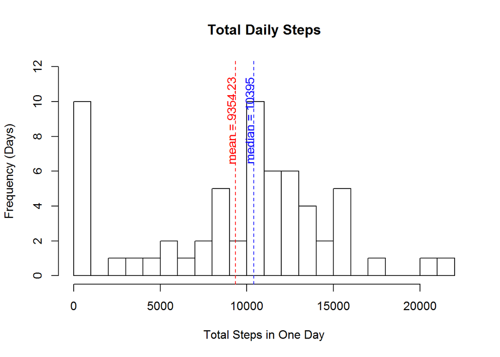

```r
xaxis <- c(0, 22000)
yaxis <- c(0,12)
hist(activitySum$dailySteps, breaks=25,
        main = "Total Daily Steps", xlab= "Total Steps in One Day",
        ylab="Frequency (Days)",
        xlim=xaxis, ylim=yaxis)

abline(v=mean(activitySum$dailySteps), col="red", lty=2) # add v line for mean
text(9354.23,8.5, "mean = 9354.23", pos=3, col="red", srt=90) # label mean line
abline(v=median(activitySum$dailySteps), col="blue", lty=2) # add v line for med
text(10395,8.5, "median = 10395", pos=3, col="blue", srt=90) # label median line
```

The mean total number of steps taken per day is 9354.23.  
The median total number of steps taken per day is 10395.

## 2. What is the average daily activity pattern?

2.1. Compute mean steps by interval

```r
activityPattern <- ddply(activity, .(interval), summarize,
        avgSteps=mean(steps, na.rm=TRUE)) # avg steps by interval
```

2.2. Make time series (line graph) of steps by interval

```r
yaxis3=c(0, 250)
plot(activityPattern$interval, activityPattern$avgSteps, type="l",
        main = "Average Steps by Daily Interval",
        xlab="Time of Day (in five minute intervals)",
        ylab= "Average Steps Taken in Interval", # line plot
        ylim=yaxis3)

subset(activityPattern$interval,
       activityPattern$avgSteps==max(activityPattern$avgSteps))
```

```
## [1] 835
```

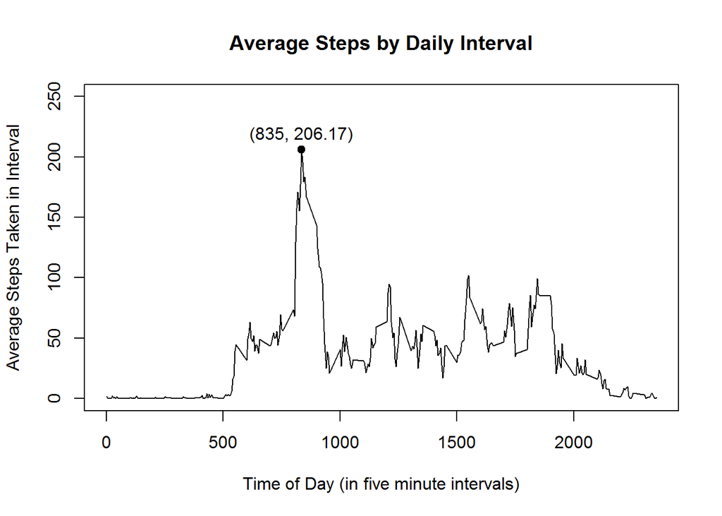

```r
text(835, max(activityPattern$avgSteps), "(835, 206.17)", pos=3)
points(835, 206.17, pch=19) # plot and label max steps point
```

Averaged across all days in the dataset, the five-minute interval with the maximum number of steps is the interval 835, or 8:35-8:40AM.

## 3. Imputing missing values

3.1. Look for a pattern: Are missing values spaced randomly or are entire days missing?

First, we plot NA’s to look for a pattern.

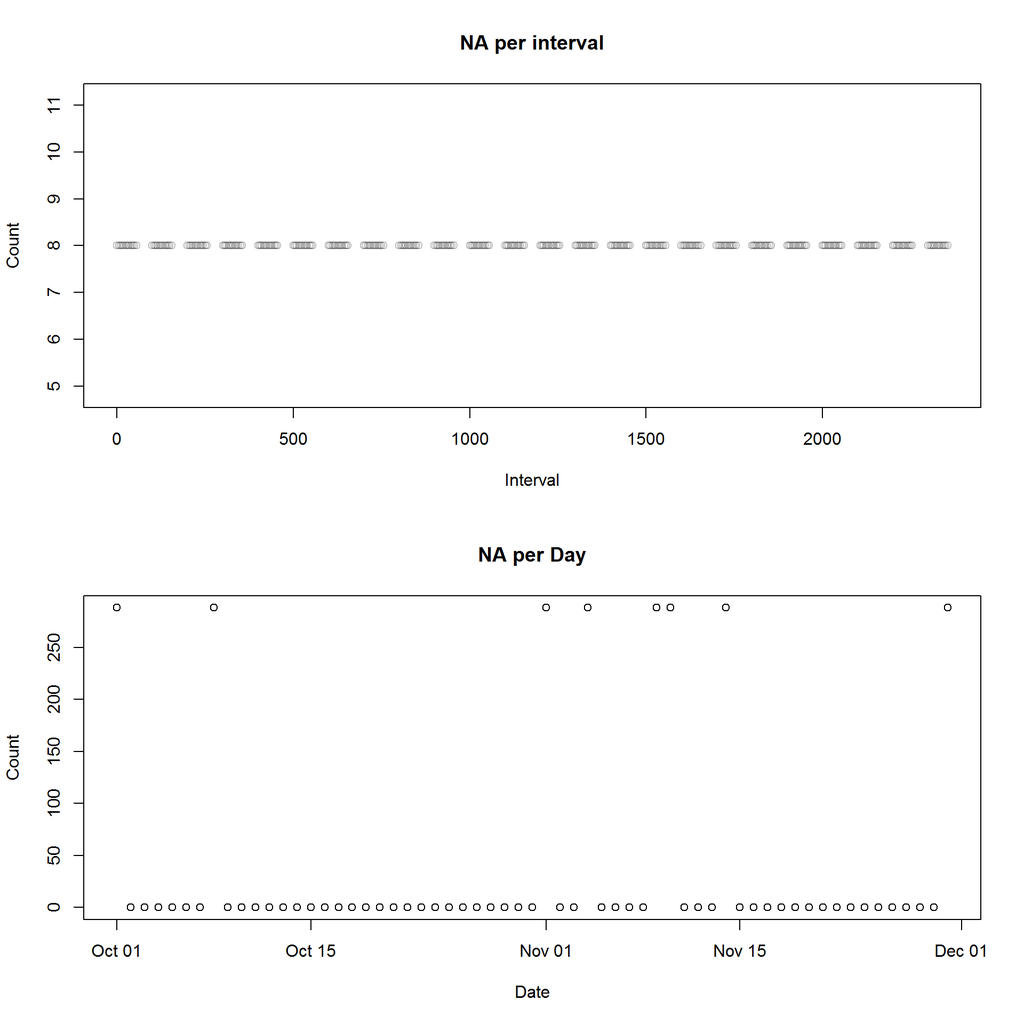

```r
naPerInterval <- tapply(activity$steps, activity$interval, function(x)
{sum(is.na(x))})
naPerDay <- tapply(activity$steps, activity$date, function(x){sum(is.na(x))})

par(mfrow=c(2,1))
plot(row.names(naPerInterval), naPerInterval, xlab="Interval",
     ylab="Count", main = "NA per interval",
     col=rgb(red=0, green=0, blue=0, alpha=0.25))
plot(as.Date(row.names(naPerDay)), naPerDay, xlab="Date", ylab="Count",
     main = "NA per Day")
```

The plots show that (1) all intervals are missing eight values, and (2) there are eight days with missing values.

To explore further, we look at the missing value counts:

```r
sum(is.na(activity$steps)) # returns missing num of steps values
```

```
## [1] 2304
```

```r
means <- ddply(activity, .(date), summarize,
               dailySteps=mean(steps, na.rm=TRUE)) # mean steps by day
sum(is.na(means$dailySteps)) # returns number of days with all steps data missing
```

```
## [1] 8
```

```r
length(unique(activity$interval)) # returns number of intervals in a day
```

```
## [1] 288
```

There are 2304 missing values. Note that there are 288 intervals in a day times 8 days completely missing = 2304 missing values; all missing values are from completely empty days.

3.2. Replace NA’s with interval means from the whole data set

```r
activityNoNa <- activity # make a copy to preserve integrity of original dataset
activityNoNa$means <- aggregate(steps ~ interval, data=activity, mean,
                                na.rm=TRUE )[,"steps"] # mean steps by interval
activityNoNa$steps[is.na(activityNoNa$steps)] <- activityNoNa$means[
        is.na(activityNoNa$steps)] # replace NA's with corresponding means
sum(is.na(activityNoNa$steps)) # verify that there are now 0 na's
```

```
## [1] 0
```

There are now 0 missing values.

3.3. Sum steps by date, with missing values imputed

```r
activitySum2 <- ddply(activityNoNa, .(date), summarize,
        dailySteps=sum(steps, na.rm=TRUE))
```

3.4. Plot histogram of total steps per day

```r
xaxis2 <- c(0, 25000)
yaxis2 <- c(0,20)
hist(activitySum2$dailySteps, breaks=25,
     main = "Total Daily Steps - Missing Data Imputed",
     xlab= "Total Steps in One Day", ylab="Frequency (Days)",
     ylim = yaxis2, xlim=xaxis2) # histogram

mean(activitySum2$dailySteps)
```

```
## [1] 10766.19
```

```r
median(activitySum2$dailySteps)
```

```
## [1] 10766.19
```

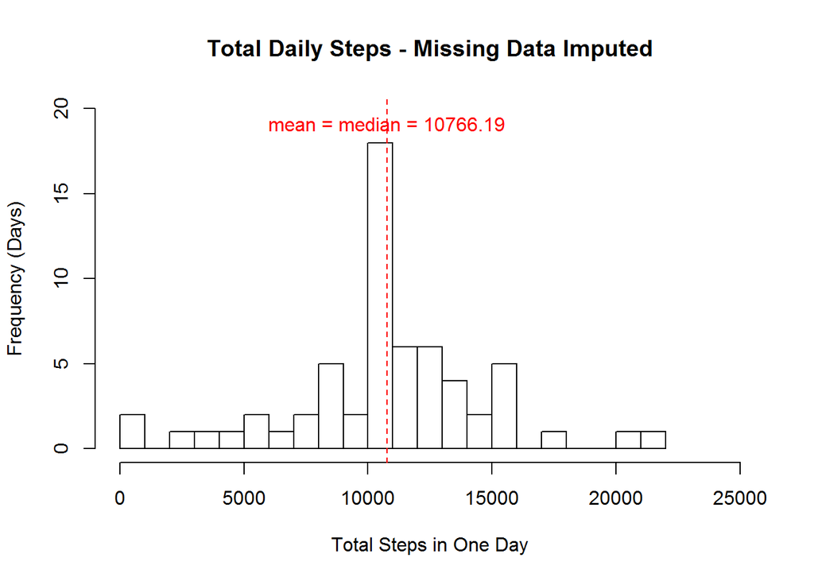

```r
abline(v=mean(activitySum2$dailySteps), col="red", lty=2) #add v line for mean
text(10766.19,18, "mean = median = 10766.19", pos=3, col="red") #label mean line
```

Interpretation: imputing missing values makes the mean equal to median equal to 10766 because the imputation process used here sets entire days of missing values equal to the by-interval mean. Recall that this is so because all missing values come from days that are entirely missing number-of-steps data.

Thus,the mean steps on dayscomposed entirely of imputed missing values becomes the mean of all days. Because eight days, sitting right in the middle of the number-of-steps distribution now take on that mean daily value, 10766 becomes the median as well.

Additionally, both mean and median are larger now than when NA’s were ignored because those days previously contributed zero to the overall mean?

## 4. Are there differences in activity patterns between weekdays and weekends?

4.1. Extract day of week from date into a new factor variable

```r
activityNoNa$date <- as.Date(activityNoNa$date, "%Y-%m-%d") # format as date
activityNoNa$dayOfWeek <- weekdays(activityNoNa$date, abbreviate = FALSE) #get days
activityNoNa$weekendWeekday = as.factor(ifelse(activityNoNa$dayOfWeek=="Sunday" |
        activityNoNa$dayOfWeek=="Saturday","weekend", "weekday")) #create new var
```

4,2. Compute average steps per intervals across weekdays, weekends

```r
activityDays <- ddply(activityNoNa, .(interval, weekendWeekday), summarize,
        avgSteps=mean(steps))
```

4.3. Make a time series (line plot) of steps by interval, by wkend/wkday

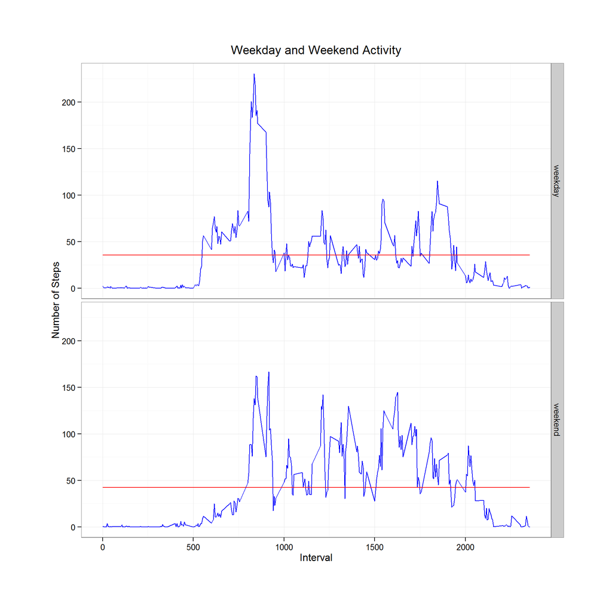

```r
library(ggplot2)
library(grid)

activityDays$means <- tapply(activityDays$avgSteps, activityDays$weekendWeekday,
        mean) # adds a mean for weekends/weekdays to the original df

weekdays <- subset(activityDays$avgSteps, activityDays$weekendWeekday=="weekday")
weekends <- subset(activityDays$avgSteps, activityDays$weekendWeekday=="weekend")

h <- qplot(interval, avgSteps, data=activityDays, facets = weekendWeekday~.,
           geom="line")
h + geom_line(colour="blue") + # add line between points
        geom_line(aes(y=means), color = "red") + # add mean lines
        labs(x="Interval",
                y="Number of Steps", title="Weekday and Weekend Activity") +
        theme_bw() +  # change to barebones theme
        theme(
                plot.margin = unit(c(2,2,2,2), "cm"), # widen top margin
                plot.title=element_text(vjust=1.5)) # move main title up
```

Activity is slightly higher on weekends: the mean steps per interval on weekdays is 35.61 and the mean steps per interval on weekends is greater at 42.37. Additionally, there is a more pronounced activity spike between the 800 and 900 intervals of weekday days, corresponding to 8:00-9:00 AM, compared to weekend days, likely due to morning work preparations on weekdays only.